# Elastic Net Regression with Boruta Feature Selection for Quantifying Coffee Adulteration: Raw Spectra

Author

Derick Malavi

## Introduction

Coffee adulteration, such as blending premium Arabica with lower-cost Robusta, undermines quality and authenticity, posing significant challenges for consumers, producers, and regulators. High-dimensional spectroscopic data provides valuable insights for detecting such fraud, but the large number of variables necessitates effective techniques to manage dimensionality and isolate the most relevant wavelengths.

This study employs Elastic Net regression, a robust technique that combines the strengths of elastic_net (L1 regularization) and Ridge (L2 regularization). Elastic Net balances feature selection and coefficient shrinkage, effectively addressing multicollinearity while retaining critical spectral features. This approach enables efficient modeling with high-dimensional data by reducing redundancy and improving prediction accuracy.

```r
# Load libraries
warning = FALSE
  suppressWarnings(suppressMessages({
  library(caret)
  library(GA)
  library(glmnet)
  library(viridis)
  library(Boruta)
  library(ggplot2)
  library(dplyr)
  library(readxl)
  library(readr)
  library(janitor)
  library(class)
  library(MLmetrics)
  library(MLeval)
  library(themis)
  library(ROSE)
  library(parallel)
  library(doParallel)
  library(foreach)
  library(pheatmap)
  library(mdatools)
  library(nnet)
  library(DMwR)
  library(e1071)
  library(knitr)
  library(pROC)
  library(gridExtra)
  library(FactoMineR)
  library(doSNOW)
  library(MASS)
  library(factoextra)
  library(kernlab)}))
```

## Prepare Data

```r
# Load data: raw spectra

hsi_raw <- read.csv("coffee_data_pycleaned.csv")

# Ensure we have the same number of dimensions and the range of our columns/covariates
dim(hsi_raw)
```

```
[1] 1469  229
```

```r
# Check a few column names
col_check <- colnames(hsi_raw[,c(1:6)])
col_check
```

```
[1] "sample_id"     "binary_class"  "three_class"   "adult_percent"
[5] "cal_val"       "X935.609985"
```

```r
# our response variable (adulteration percentage) is column 4
# The spectral values start from column # 6 -------> 229

# Convert the adulteration percentage to numeric for compatibility with ML
hsi_raw$adult_percent <- as.numeric(hsi_raw$adult_percent)
```

## Get the X and y variables

```r
X <- hsi_raw[,c(6:229)]
y <- hsi_raw[,4]

class(y) #Ensure y (target variable) is a numeric for regression
```

```
[1] "numeric"
```

## Visualize X

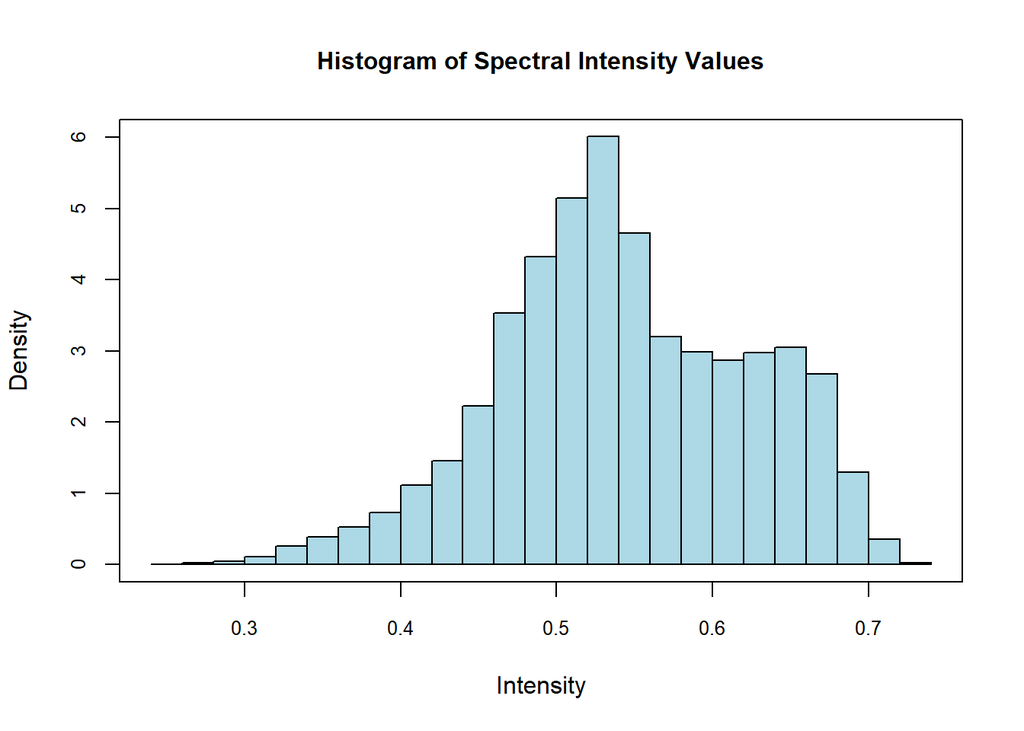

```r
hist(as.matrix(X), col = 'lightblue', cex.main = 1.0,
     cex.axis = 0.8,cex.lab = 1.0, freq= FALSE,
     main = 'Histogram of Spectral Intensity Values', xlab = 'Intensity'); box()
```

## Split the Data (Train_Test Split)

- We want to select features based on training data only to avoid any data leakage that could inflate model performance and make the model less generalizable to unseen data.

```r
# Subset samples for cross-validation and external validation (70/30)
# Record 1 under cal_val variable is for calibration while 2 will be for testing the model

sample<-hsi_raw$cal_val == 1

# Split to train and test sets
X_train <- X[sample,]
X_test <- X[!sample,]
y_train <-y[sample]
y_test <- y[!sample]

# Check length of the subsets for training and validation
dim(X_train)
```

```
[1] 1055  224
```

```r
dim(X_test)
```

```
[1] 414 224
```

```r
length(y_train)
```

```
[1] 1055
```

```r
length(y_test)
```

```
[1] 414
```

```r
# Merge the test and train data
train_data <- data.frame(X_train, y_train)
test_data <- data.frame(X_test, y_test)
```

## Run Boruta Algorithm for Optimum Wavelength Selection

```r
  # Set seed for reproducibility
  set.seed(123)

  # Set the dataset name dynamically
  dataset_name <- "raw"

  # Define paths for the execution flag and Boruta result
  flag_file <- paste0("boruta_executed_flag_", dataset_name, ".RData")
  result_file <- paste0("boruta_result_", dataset_name, ".RData")

  # Register cluster for caret to train the models in parallel
  cl <- makeCluster(6, type = "SOCK")
  suppressWarnings(suppressMessages(registerDoSNOW(cl)))

if (!file.exists(result_file)) {
  message(paste("Starting Boruta execution for dataset:", dataset_name))

  # Start the timer
  start_time <- Sys.time()

  # Run Boruta on the train data set
  boruta_result <- Boruta(formula = y_train ~ .,
                        data = train_data,
                        doTrace = 2,
                        maxRuns = 100)

  # Stop the cluster
  stopCluster(cl)

  # Register end time
  end_time <- Sys.time()
  print(paste('Time to run the Boruta model:', end_time - start_time))

  # Save Boruta results and execution flag
  boruta_executed <- TRUE
  save(boruta_executed, file = flag_file)
  save(boruta_result, file = result_file)


  message(paste("Boruta execution completed for dataset:", dataset_name, "and results saved."))

} else {
  # Load previously saved results
  message(paste("Result file found. Loading saved Boruta results for dataset:", dataset_name))
  load(result_file)
  load(flag_file)
  message(paste("Boruta already executed for dataset:", dataset_name))
}
```

```
Result file found. Loading saved Boruta results for dataset: raw
```

```
Boruta already executed for dataset: raw
```

```r
# Print Boruta summary
print(boruta_result)
```

```
Boruta performed 99 iterations in 9.471045 mins.
 201 attributes confirmed important: X1001.369995, X1004.830017,
X1008.299988, X1011.77002, X1015.23999 and 196 more;
 No attributes deemed unimportant.
 23 tentative attributes left: X1175.390015, X1178.890015,
X1182.380005, X1185.880005, X1227.869995 and 18 more;
```

```r
# Get selected features
final_features <- getSelectedAttributes(boruta_result, withTentative = FALSE)
final_features
```

```
  [1] "X935.609985"  "X939.059998"  "X942.52002"   "X945.97998"   "X949.429993"
  [6] "X952.890015"  "X956.349976"  "X959.809998"  "X963.27002"   "X966.72998"
 [11] "X970.190002"  "X973.650024"  "X977.109985"  "X980.580017"  "X984.039978"
 [16] "X987.51001"   "X990.969971"  "X994.429993"  "X997.900024"  "X1001.369995"
 [21] "X1004.830017" "X1008.299988" "X1011.77002"  "X1015.23999"  "X1018.710022"
 [26] "X1022.179993" "X1025.650024" "X1029.119995" "X1032.589966" "X1036.060059"
 [31] "X1039.530029" "X1043"        "X1046.47998"  "X1049.949951" "X1053.430054"
 [36] "X1056.900024" "X1060.380005" "X1063.849976" "X1067.329956" "X1070.810059"
 [41] "X1074.290039" "X1077.76001"  "X1081.23999"  "X1084.719971" "X1088.199951"
 [46] "X1091.680054" "X1095.170044" "X1098.650024" "X1102.130005" "X1105.609985"
 [51] "X1109.099976" "X1112.579956" "X1116.069946" "X1119.550049" "X1123.040039"
 [56] "X1126.52002"  "X1130.01001"  "X1133.5"      "X1136.98999"  "X1140.469971"
 [61] "X1143.959961" "X1147.449951" "X1150.939941" "X1154.430054" "X1157.930054"
 [66] "X1161.420044" "X1164.910034" "X1168.400024" "X1171.900024" "X1189.369995"
 [71] "X1192.869995" "X1196.369995" "X1199.869995" "X1203.369995" "X1206.869995"
```

[output cut: 26 more lines]

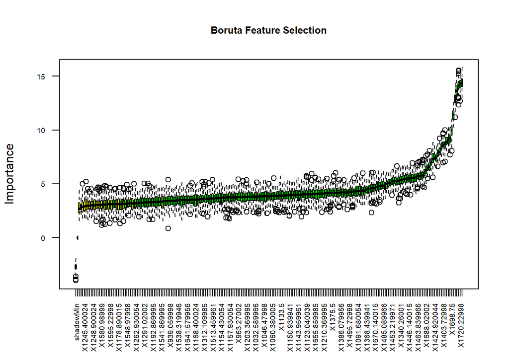

```r
# Plot Boruta results
plot(boruta_result, xlab = "", las = 2,
     cex.main = 0.8, cex.axis = 0.6,
     main = paste("Boruta Feature Selection"))
```

```r
print(paste('The number of selected variables are', length(final_features)))
```

```
[1] "The number of selected variables are 201"
```

## Create a Data frame with the Selected Features

```r
# Subset the training and test data using the selected features
X_train_selected <- X_train[, final_features]
X_test_selected <- X_test[, final_features]

# Keep y_train and y_test as-is
y_train_selected <- y_train
y_test_selected <- y_test


#Merge data_frame
train_merged <- cbind(y_train = y_train_selected, X_train_selected)
test_merged <- cbind(y_test = y_test_selected, X_test_selected)

dim(train_merged)
```

```
[1] 1055  202
```

```r
dim(test_merged)
```

```
[1] 414 202
```

## Check correlations by HeatMaps

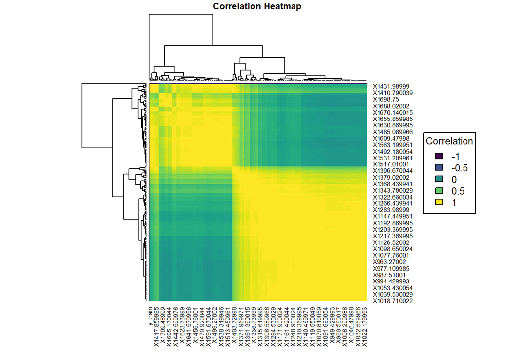

```r
n_features <- length(final_features)

#Calculate correlations
corr <- cor(train_merged[, -(n_features+1)])

# Create a heat map
par(cex.main = 0.6)
heatmap(corr, symm = TRUE,
        col = viridis(50),
        main = "Correlation Heatmap")

# Add legend

legend("right",
       legend = seq(-1, 1, by = 0.5),  # Correlation range
       fill = viridis(5),
       title = "Correlation", cex = 0.8)
```

## Train Models

- We will train models based on the reduced number of features.

```r
# Set random seed for reproducibility
set.seed (123)

# Set up the training control(10 folds 10 times cross_validation)
control <- trainControl(method = "repeatedcv", number = 10, repeats = 10,
                        savePredictions = "final",
                        summaryFunction = defaultSummary,
                        selectionFunction = 'best', allowParallel = TRUE)

# We used oneSE for classification. For regression, we will use 'best': a model that minimizes RMSECV
```

```r
#Set the metric as accuracy
metric<-"RMSE"
```

```r
# Hyperparameter set Elastic Net Regression
# alpha: Set for L1(elastic_net) and L2(Ridge) Regression
# lambda: Regularization strength (penalty parameter). A sequence of values is tested to identify the best lambda.

grid <- expand.grid( alpha = seq(0, 1, length = 10),  # Explore between Ridge (alpha = 0) and elastic_net (alpha = 1)
    lambda = seq(0.001, 0.1, length = 10))
```

# Train Elastic Net

```r
set.seed(123)
#Register cluster for caret to train the models in parallel
cl<-makeCluster(6,type = "SOCK")
suppressWarnings(suppressMessages(
  registerDoSNOW(cl)))

# Start_time
start_time<-Sys.time()

#Train the model using cross-validation (10 folds, 10 times)
fit_elastic_net_raw<-train(y = train_merged[,1],
                         x = train_merged[,-1],
                         method = 'glmnet', tuneGrid = grid,
                         trControl = control, preProcess = c("center","scale"),
                         metric = metric)
#End_time
end_time<-Sys.time()

model_training_time<-end_time-start_time

stopCluster(cl) # Stop the parallel run cluster

print(model_training_time)
```

```
Time difference of 9.660343 mins
```

```r
# Display regression results
print(fit_elastic_net_raw)
```

```
glmnet

1055 samples
 201 predictor

Pre-processing: centered (201), scaled (201)
Resampling: Cross-Validated (10 fold, repeated 10 times)
Summary of sample sizes: 949, 949, 949, 948, 949, 950, ...
Resampling results across tuning parameters:

  alpha      lambda  RMSE       Rsquared   MAE
  0.0000000  0.001   11.976433  0.8286366  9.402196
  0.0000000  0.012   11.976433  0.8286366  9.402196
  0.0000000  0.023   11.976433  0.8286366  9.402196
  0.0000000  0.034   11.976433  0.8286366  9.402196
  0.0000000  0.045   11.976433  0.8286366  9.402196
  0.0000000  0.056   11.976433  0.8286366  9.402196
  0.0000000  0.067   11.976433  0.8286366  9.402196
  0.0000000  0.078   11.976433  0.8286366  9.402196
  0.0000000  0.089   11.976433  0.8286366  9.402196
  0.0000000  0.100   11.976433  0.8286366  9.402196
  0.1111111  0.001    9.251438  0.8977676  7.323224
  0.1111111  0.012    9.251438  0.8977676  7.323224
  0.1111111  0.023    9.394912  0.8945393  7.418324
  0.1111111  0.034    9.686188  0.8878124  7.610276
  0.1111111  0.045    9.893862  0.8828839  7.749347
  0.1111111  0.056   10.062510  0.8788056  7.863901
  0.1111111  0.067   10.202262  0.8753758  7.960119
  0.1111111  0.078   10.318669  0.8724877  8.042363
  0.1111111  0.089   10.423302  0.8698622  8.118184
  0.1111111  0.100   10.508488  0.8677151  8.181363
  0.2222222  0.001    8.814072  0.9073959  7.011441
  0.2222222  0.012    8.917475  0.9051859  7.083097
  0.2222222  0.023    9.376571  0.8950014  7.399134
  0.2222222  0.034    9.728415  0.8868193  7.633880
  0.2222222  0.045   10.030852  0.8795514  7.836133
  0.2222222  0.056   10.242650  0.8743758  7.982193
  0.2222222  0.067   10.367926  0.8712555  8.071458
  0.2222222  0.078   10.490792  0.8681334  8.160604
  0.2222222  0.089   10.619186  0.8648528  8.257288
```

[output cut: 59 more lines]

```
  0.8888889  0.089   11.471182  0.8421874  8.921652
  0.8888889  0.100   11.534090  0.8405043  8.969341
  1.0000000  0.001    8.375460  0.9162723  6.662019
  1.0000000  0.012    8.928261  0.9049661  7.047313
  1.0000000  0.023    9.737427  0.8866474  7.597433
  1.0000000  0.034   10.397264  0.8705105  8.071192
  1.0000000  0.045   10.742595  0.8616467  8.340683
  1.0000000  0.056   11.131532  0.8513265  8.657143
  1.0000000  0.067   11.393069  0.8442378  8.866380
  1.0000000  0.078   11.457601  0.8425318  8.909397
  1.0000000  0.089   11.530441  0.8405662  8.966597
  1.0000000  0.100   11.606600  0.8385050  9.029991

RMSE was used to select the optimal model using the smallest value.
The final values used for the model were alpha = 0.8888889 and lambda = 0.001.
```

#### Best hyperparameters

```r
# Best lambda value
best_lambda <- fit_elastic_net_raw$bestTune$lambda

cat("Best Lambda:", best_lambda, "\n")
```

```
Best Lambda: 0.001
```

#### Extract Selected Features

```r
# Extract coefficients from the best model
coefficients <- coef(fit_elastic_net_raw$finalModel, s = best_lambda)

# Convert to a readable format
elastic_net_coefficients <- as.data.frame(as.matrix(coefficients))
colnames(elastic_net_coefficients) <- "Coefficient"
elastic_net_coefficients$Variable <- rownames(elastic_net_coefficients)

# Filter non-zero coefficients (selected features)
selected_features <- elastic_net_coefficients[elastic_net_coefficients$Coefficient != 0, ]
print(selected_features)
```

```
               Coefficient     Variable
(Intercept)   3.016019e+01  (Intercept)
X935.609985  -1.258396e+00  X935.609985
X942.52002   -1.169392e+01   X942.52002
X949.429993   4.117283e+00  X949.429993
X970.190002  -2.340642e-04  X970.190002
X994.429993  -8.656279e-01  X994.429993
X1001.369995 -1.247208e+00 X1001.369995
X1008.299988 -2.514487e+00 X1008.299988
X1029.119995  1.019175e+00 X1029.119995
X1032.589966  5.936123e-01 X1032.589966
X1043         2.198221e-04        X1043
X1046.47998   3.493710e-04  X1046.47998
X1049.949951  5.022253e+00 X1049.949951
X1053.430054  7.493018e+00 X1053.430054
X1056.900024  4.248721e+00 X1056.900024
X1060.380005  4.216452e+00 X1060.380005
X1063.849976  1.066198e-01 X1063.849976
X1074.290039  5.869112e-01 X1074.290039
X1077.76001   3.793421e+00  X1077.76001
X1088.199951  3.985495e-01 X1088.199951
X1091.680054  8.221094e+00 X1091.680054
X1102.130005  1.326213e+01 X1102.130005
X1116.069946  1.048636e+01 X1116.069946
X1119.550049  1.698651e+01 X1119.550049
X1123.040039  2.276295e+00 X1123.040039
X1126.52002   5.443162e+00  X1126.52002
X1130.01001   4.186199e-04  X1130.01001
X1133.5       7.283093e-01      X1133.5
X1136.98999   3.758949e+00  X1136.98999
X1140.469971  6.659146e+00 X1140.469971
X1143.959961  3.163125e+00 X1143.959961
X1147.449951  1.834098e+00 X1147.449951
X1150.939941  1.186629e+00 X1150.939941
X1154.430054  1.497450e+00 X1154.430054
X1157.930054  5.825874e-01 X1157.930054
X1168.400024 -5.841751e-04 X1168.400024
X1171.900024 -2.631713e+01 X1171.900024
X1189.369995 -4.078780e+01 X1189.369995
X1192.869995 -3.386172e+01 X1192.869995
```

[output cut: 74 more lines]

```
X1670.140015 -7.548109e+01 X1670.140015
X1673.719971 -8.741029e+01 X1673.719971
X1677.290039 -5.026566e+01 X1677.290039
X1680.869995  1.181261e-03 X1680.869995
X1684.439941  4.507511e-03 X1684.439941
X1688.02002   6.854595e+01  X1688.02002
X1691.589966  1.410011e+02 X1691.589966
X1695.170044  3.948003e+00 X1695.170044
X1698.75     -3.733194e-04     X1698.75
X1702.329956  2.374170e+01 X1702.329956
X1705.910034  2.185967e+00 X1705.910034
X1709.48999  -1.804570e+01  X1709.48999
X1713.069946 -1.958784e+01 X1713.069946
X1716.650024  8.242269e+00 X1716.650024
X1720.22998   5.584167e-01  X1720.22998
```

```r
# Sort the selected features by actual values in descending order
selected_features_sorted_actual <- selected_features[order(selected_features$Coefficient, decreasing = TRUE), ]

# Print the sorted features
print(selected_features_sorted_actual)
```

```
               Coefficient     Variable
X1691.589966  1.410011e+02 X1691.589966
X1634.439941  7.076132e+01 X1634.439941
X1688.02002   6.854595e+01  X1688.02002
X1623.73999   6.543462e+01  X1623.73999
X1474.459961  6.374210e+01 X1474.459961
X1563.199951  4.561470e+01 X1563.199951
X1379.02002   4.453067e+01  X1379.02002
X1638.01001   4.335478e+01  X1638.01001
X1620.170044  3.795640e+01 X1620.170044
X1417.859985  3.728791e+01 X1417.859985
(Intercept)   3.016019e+01  (Intercept)
X1460.300049  2.903465e+01 X1460.300049
X1702.329956  2.374170e+01 X1702.329956
X1382.550049  2.262143e+01 X1382.550049
X1421.390015  2.256781e+01 X1421.390015
X1119.550049  1.698651e+01 X1119.550049
X1467.380005  1.361392e+01 X1467.380005
X1102.130005  1.326213e+01 X1102.130005
X1449.680054  1.286202e+01 X1449.680054
X1116.069946  1.048636e+01 X1116.069946
X1456.76001   9.154812e+00  X1456.76001
X1559.640015  8.760530e+00 X1559.640015
X1470.920044  8.441892e+00 X1470.920044
X1716.650024  8.242269e+00 X1716.650024
X1091.680054  8.221094e+00 X1091.680054
X1463.839966  7.608920e+00 X1463.839966
X1053.430054  7.493018e+00 X1053.430054
X1140.469971  6.659146e+00 X1140.469971
X1308.589966  6.625418e+00 X1308.589966
X1126.52002   5.443162e+00  X1126.52002
X1049.949951  5.022253e+00 X1049.949951
X1224.369995  4.598435e+00 X1224.369995
X1056.900024  4.248721e+00 X1056.900024
X1060.380005  4.216452e+00 X1060.380005
X949.429993   4.117283e+00  X949.429993
X1695.170044  3.948003e+00 X1695.170044
X1077.76001   3.793421e+00  X1077.76001
X1136.98999   3.758949e+00  X1136.98999
X1319.140015  3.398291e+00 X1319.140015
```

[output cut: 74 more lines]

```
X1517.01001  -2.472411e+01  X1517.01001
X1648.709961 -2.558137e+01 X1648.709961
X1171.900024 -2.631713e+01 X1171.900024
X1513.459961 -2.954048e+01 X1513.459961
X1192.869995 -3.386172e+01 X1192.869995
X1199.869995 -4.065431e+01 X1199.869995
X1189.369995 -4.078780e+01 X1189.369995
X1659.430054 -4.833028e+01 X1659.430054
X1677.290039 -5.026566e+01 X1677.290039
X1439.069946 -5.520204e+01 X1439.069946
X1435.530029 -6.865699e+01 X1435.530029
X1670.140015 -7.548109e+01 X1670.140015
X1652.290039 -8.684123e+01 X1652.290039
X1673.719971 -8.741029e+01 X1673.719971
X1509.910034 -8.859557e+01 X1509.910034
```

```r
print(paste('The number of feautures selected by elastic_net are', nrow(selected_features_sorted_actual)))
```

```
[1] "The number of feautures selected by elastic_net are 128"
```

## Save the models for future use

```r
saveRDS(fit_elastic_net_raw, "fit_elastic_net_raw.rds")
```

### Variable Importance Plot

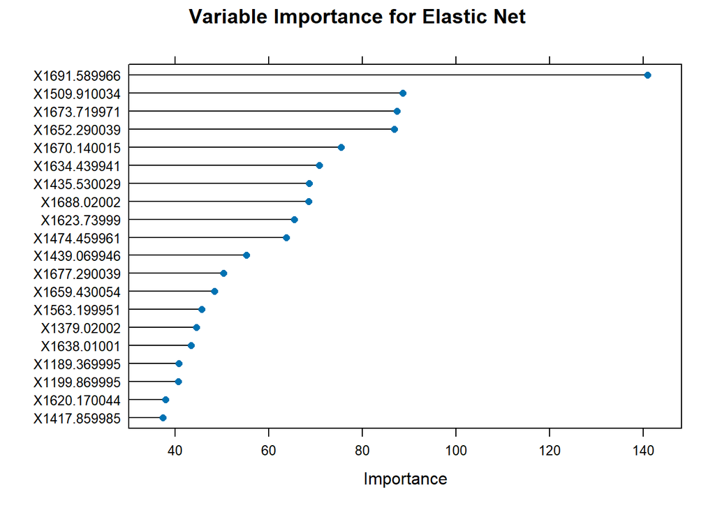

```r
# Calculate variable importance
importance <- varImp(fit_elastic_net_raw, scale = FALSE)

# Plot variable importance
plot(importance, top = 20, main = "Variable Importance for Elastic Net")
```

#### Coefficients vs. Lambda Path

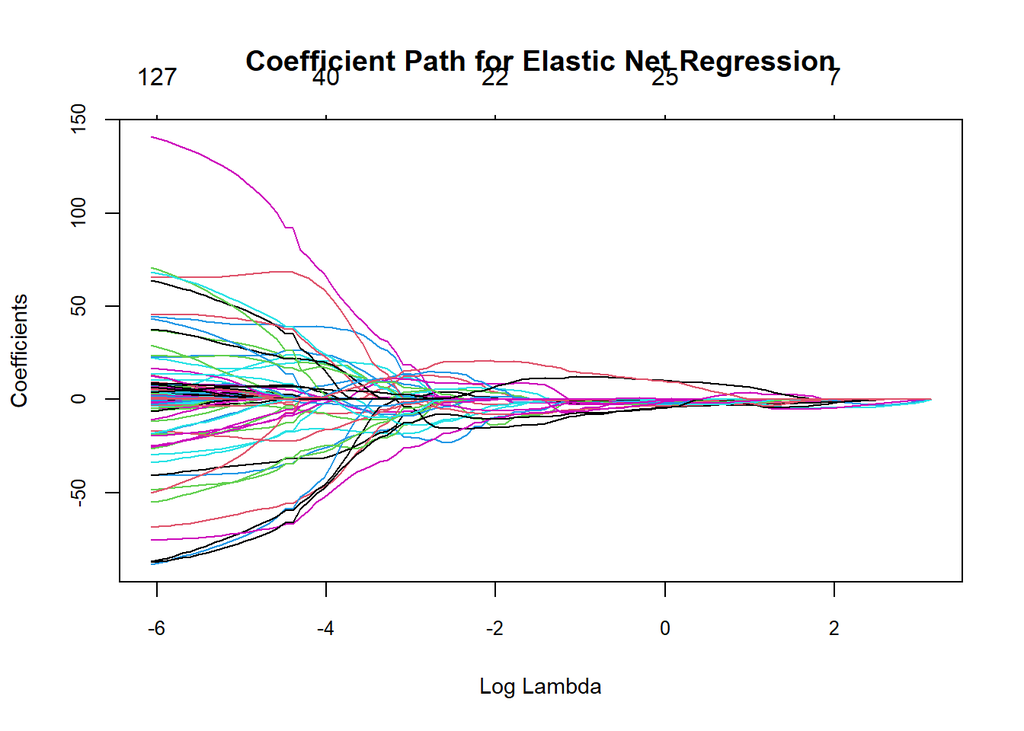

```r
# Extract the final glmnet model
fit_glmnet <- fit_elastic_net_raw$finalModel

# Plot coefficients vs. lambda
plot(
  fit_glmnet,
  xvar = "lambda",
  label = FALSE,
  cex.axis = 0.8,
  cex.lab = 0.9,
  cex.main = 0.3)
title(main = "Coefficient Path for Elastic Net Regression")
```

```r
# As lambda increases, coefficients shrink toward zero, highlighting the feature selection process
```

## Display CV Results in Tables

```r
kable(fit_elastic_net_raw$results)
```

| alpha | lambda | RMSE | Rsquared | MAE | RMSESD | RsquaredSD | MAESD |
| --- | --- | --- | --- | --- | --- | --- | --- |
| 0.0000000 | 0.001 | 11.976433 | 0.8286366 | 9.402196 | 0.9476635 | 0.0256915 | 0.6324995 |
| 0.0000000 | 0.012 | 11.976433 | 0.8286366 | 9.402196 | 0.9476635 | 0.0256915 | 0.6324995 |
| 0.0000000 | 0.023 | 11.976433 | 0.8286366 | 9.402196 | 0.9476635 | 0.0256915 | 0.6324995 |
| 0.0000000 | 0.034 | 11.976433 | 0.8286366 | 9.402196 | 0.9476635 | 0.0256915 | 0.6324995 |
| 0.0000000 | 0.045 | 11.976433 | 0.8286366 | 9.402196 | 0.9476635 | 0.0256915 | 0.6324995 |
| 0.0000000 | 0.056 | 11.976433 | 0.8286366 | 9.402196 | 0.9476635 | 0.0256915 | 0.6324995 |
| 0.0000000 | 0.067 | 11.976433 | 0.8286366 | 9.402196 | 0.9476635 | 0.0256915 | 0.6324995 |
| 0.0000000 | 0.078 | 11.976433 | 0.8286366 | 9.402196 | 0.9476635 | 0.0256915 | 0.6324995 |
| 0.0000000 | 0.089 | 11.976433 | 0.8286366 | 9.402196 | 0.9476635 | 0.0256915 | 0.6324995 |
| 0.0000000 | 0.100 | 11.976433 | 0.8286366 | 9.402196 | 0.9476635 | 0.0256915 | 0.6324995 |
| 0.1111111 | 0.001 | 9.251437 | 0.8977676 | 7.323224 | 0.7717283 | 0.0157692 | 0.5664689 |
| 0.1111111 | 0.012 | 9.251437 | 0.8977676 | 7.323224 | 0.7717283 | 0.0157692 | 0.5664689 |
| 0.1111111 | 0.023 | 9.394912 | 0.8945393 | 7.418324 | 0.7864917 | 0.0163605 | 0.5712890 |
| 0.1111111 | 0.034 | 9.686188 | 0.8878124 | 7.610276 | 0.8241282 | 0.0177247 | 0.5867574 |
| 0.1111111 | 0.045 | 9.893862 | 0.8828839 | 7.749347 | 0.8510750 | 0.0187456 | 0.5964359 |
| 0.1111111 | 0.056 | 10.062510 | 0.8788056 | 7.863901 | 0.8699782 | 0.0195387 | 0.6030338 |
| 0.1111111 | 0.067 | 10.202262 | 0.8753758 | 7.960119 | 0.8852181 | 0.0201873 | 0.6085445 |
| 0.1111111 | 0.078 | 10.318669 | 0.8724877 | 8.042363 | 0.8944828 | 0.0206550 | 0.6119615 |
| 0.1111111 | 0.089 | 10.423302 | 0.8698622 | 8.118184 | 0.9027781 | 0.0210851 | 0.6151536 |
| 0.1111111 | 0.100 | 10.508488 | 0.8677151 | 8.181363 | 0.9058335 | 0.0213460 | 0.6154005 |
| 0.2222222 | 0.001 | 8.814072 | 0.9073959 | 7.011441 | 0.6804693 | 0.0129529 | 0.5077675 |
| 0.2222222 | 0.012 | 8.917475 | 0.9051859 | 7.083097 | 0.6935256 | 0.0134209 | 0.5181613 |
| 0.2222222 | 0.023 | 9.376571 | 0.8950014 | 7.399134 | 0.7733965 | 0.0159349 | 0.5581297 |
| 0.2222222 | 0.034 | 9.728415 | 0.8868193 | 7.633880 | 0.8346147 | 0.0180218 | 0.5855169 |
| 0.2222222 | 0.045 | 10.030852 | 0.8795514 | 7.836133 | 0.8809099 | 0.0197412 | 0.6067451 |
| 0.2222222 | 0.056 | 10.242650 | 0.8743758 | 7.982193 | 0.8884577 | 0.0203521 | 0.6052107 |
| 0.2222222 | 0.067 | 10.367926 | 0.8712555 | 8.071458 | 0.8959138 | 0.0207996 | 0.6072566 |
| 0.2222222 | 0.078 | 10.490792 | 0.8681334 | 8.160604 | 0.9156729 | 0.0215599 | 0.6160898 |
| 0.2222222 | 0.089 | 10.619186 | 0.8648528 | 8.257288 | 0.9249462 | 0.0220674 | 0.6186600 |
| 0.2222222 | 0.100 | 10.733690 | 0.8618951 | 8.344925 | 0.9324827 | 0.0225044 | 0.6216373 |

[output cut: 70 more lines]

```r
# Select row for the optimal model
opt_row <- fit_elastic_net_raw$results %>%
  filter(lambda==fit_elastic_net_raw$bestTune$lambda &
           alpha == fit_elastic_net_raw$bestTune$alpha)

kable(opt_row)
```

| alpha | lambda | RMSE | Rsquared | MAE | RMSESD | RsquaredSD | MAESD |
| --- | --- | --- | --- | --- | --- | --- | --- |
| 0.8888889 | 0.001 | 8.119319 | 0.9214566 | 6.50675 | 0.6459117 | 0.011475 | 0.4979584 |

## Test the model performance on test data

```r
#Predict on the test set
observed <- test_merged$y_test
predictions <- predict(fit_elastic_net_raw,newdata=test_merged)

# Generate predictions
results <- postResample(predictions, observed)

print(results)
```

```
      RMSE   Rsquared        MAE
10.5183054  0.8933969  8.7456864
```

```r
RMSEP = results[[1]]
R2 = results[[2]]
MAE = results[[3]]

cat('The RMSEP for the model on external validation is:', RMSEP,'\n')
```

```
The RMSEP for the model on external validation is: 10.51831
```

```r
cat('The R Squared value for the model is:', R2)
```

```
The R Squared value for the model is: 0.8933969
```

```r
# Calculate Residual Predictive Deviation to check model performance

RPD = sd(observed)/RMSEP

print(paste('The RPD values for the model is', round(RPD,2)))
```

```
[1] "The RPD values for the model is 2.77"
```

## Visualizations

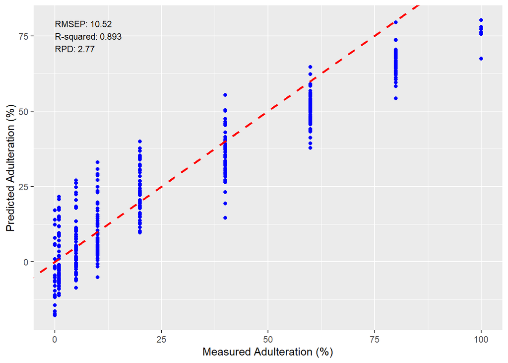

```r
# predicted vs observed line and scatter
# Create a data frame
results_df <- data.frame(observed=observed, predictions=predictions)

results_df %>%
  ggplot(aes(x = observed, y = predictions)) +
  geom_point(color = "blue") +
  geom_abline(slope = 1, intercept = 0, color = "red",
              linetype = "dashed", linewidth = 1) +
  labs( x = "Measured Adulteration (%)",
    y = "Predicted Adulteration (%)") +
  annotate("text",
    x = min(observed), y = max(predictions),
    label = paste("RMSEP:", round(RMSEP, 2),
      "\nR-squared:", round(R2, 3),
      "\nRPD:", round(RPD, 2)),
    hjust = 0, vjust = 1, size = 3, color = "black") +
  theme(
    axis.title = element_text(color = "black", size = 10),
    axis.text = element_text(color = "black"))+
  theme_gray()
```

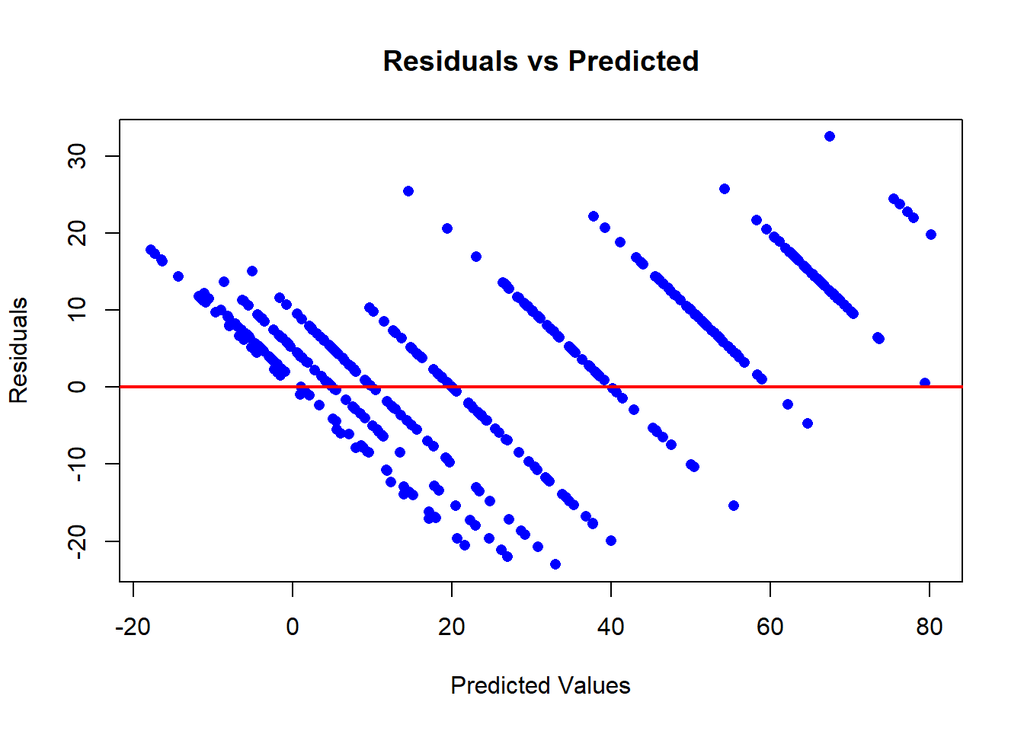

```r
# Check residuals

residuals <- observed - predictions

# Plot Residuals
plot(predictions, residuals,
     xlab = "Predicted Values",
     ylab = "Residuals",
     main = "Residuals vs Predicted",
     pch = 16, col = "blue")
abline(h = 0, col = "red", lwd = 2)
```

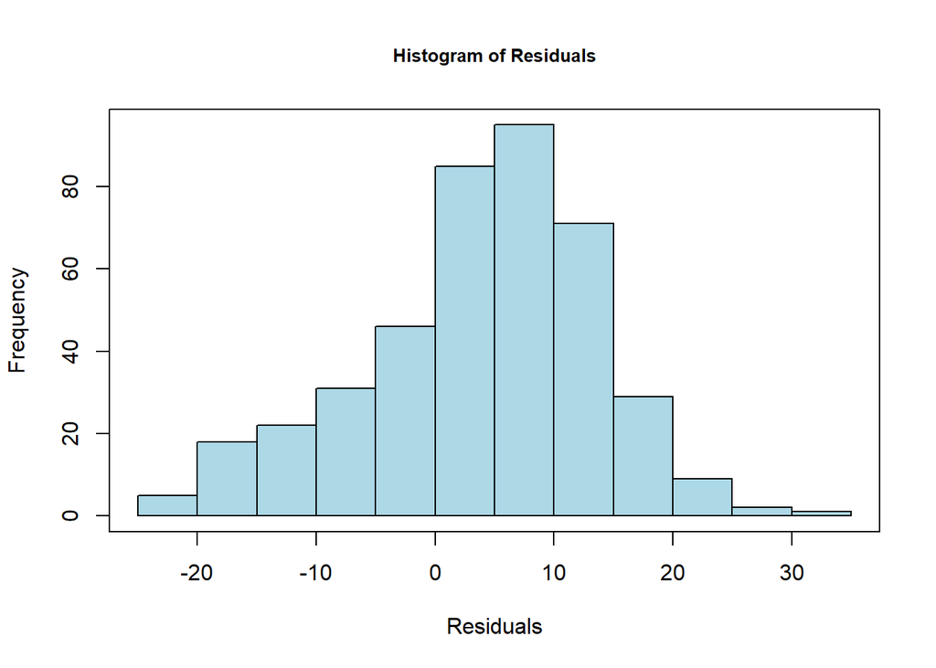

```r
hist(residuals,
     main = "Histogram of Residuals",
     xlab = "Residuals", cex.main = 0.8,
     col = "lightblue", border = "black"); box()
```

## Conclusion

- The combination of the Boruta algorithm for feature selection and Elastic Net regression showcases good predictive ability in quantifying adulteration in ground coffee. With an **RPD value of 2.8**, the model delivers reliable quantitative predictions, making it suitable for quality control applications.